# Quantile Regression: The Problem

Leonard Kunz

2021-02-07

## Quantile Regression

Have you ever thought to yourself, the mean as an estimator is incredibly prone to outliers and also gives only a snippet of the underlying distribution? …No? Me neither! However, Koenker did in 1978 and this brings us right to the wonderful world of quantile regression.

Remember quantiles? Probably some stuff like, it is immune to outliers, and maybe even, that for distribtution $F$ it holds that realizations are smaller to $q(\tau)$ with probability $\tau$ and bigger with probability $1-\tau$. So in a sense the quantile is the mitochondrion of statistics. Everyone knows its basic properties. But here I want to show you that the use of quantiles goes far beyond.

In this first part of the series I will show you, how quantile estimation can be reformulated from a sorting problem to an optimzation problem. This will bring us right to conditional quantile estimation. Since I like doing stuff the complicated way, we will implement everything in R as we go along. Note that I will also drop a good amount of mathematics because I feel that most blog posts about statistics are actually just manuals. However, we don’t only want to know how to assemble the chair but how the parts were built

### The Quantile

As said before the quantile divides the range of a probability distribution into two parts. For the $\tau$th quantile, where $\tau \in [0, 1]$, $\tau$ is the probability that a value of the random variable is smaller or equal to the $\tau$th quantile denoted as $q(\tau)$ from here on. More formally, For the distribution $F_X: \mathcal{R} \to [0, 1]$ of random variable $X$ the $\tau$th quantile satisfies:
$$F_X(x)\equiv Pr(X \le x) = \tau$$
which can be expressed as the quantile function $Q(\tau): [0, 1] \to \mathcal{R}$ defined as
$$Q(\tau) \equiv \inf{x\in \mathcal{R}: \tau \le F_X(x)}$$
To show you the intuition behind these two consider the plot below which plots the cdf and the quantile function of standard normal. See that in the case of a strictly increasing cdf the quantile function is just the inverse of the cdf $Q(\tau) = F_X^{-1}(\tau)$.

```r
# Load some packages first
library(ggplot2)
library(latex2exp)
library(quantreg)
library(tidyverse)
```

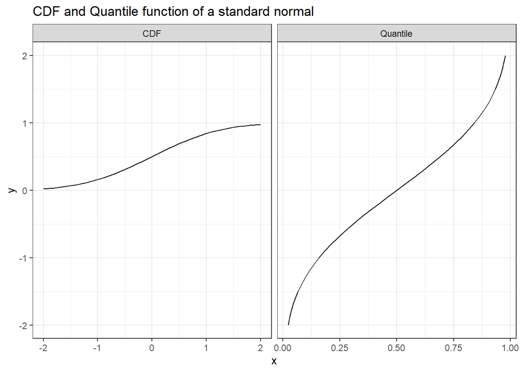

```r
set.seed(2093)
x <- seq(-2, 2, by = 0.1)
cdf_x <- pnorm(x)
quantile_fct <- qnorm(cdf_x)

# Bind data together to use facts
data_plot_1 <- rbind.data.frame(
  cbind(x = x, y = cdf_x),
  cbind(x = cdf_x, y = quantile_fct)
  )

# Create an identification column
data_plot_1$Type <- rep(c("CDF", "Quantile"), each = length(x))

# Plot of the cdf
data_plot_1 %>% ggplot(aes(x = x, y = y)) +
  geom_line() +
  facet_grid(. ~ Type, scales = "free") +
  labs(title = "CDF and Quantile function of a standard normal") +
  theme_bw()
```

### Quantile Estimation

So far so good. Estimation of quantiles is usually taught as a sorting problem. For a sample $x$ of size $n$ we order the observations and then choose $\hat{q}(\tau)$ such that $\hat{F}_X(\hat{q}(\tau)) = \tau$. What is usually not taught is, that the same problem can be solved by minimizing the function
$$\hat{q}(\tau) = \arg \min_{q \in \mathcal{R}} \sum_{i = 1}^n \rho_{\tau}(x_i - q)$$
where $\rho_{\tau} (x) \equiv x (\tau - \mathcal{I}_{x < 0})$. The loss function $\rho_{\tau}$ is an asymmetric value function. I define the function below and plot it.

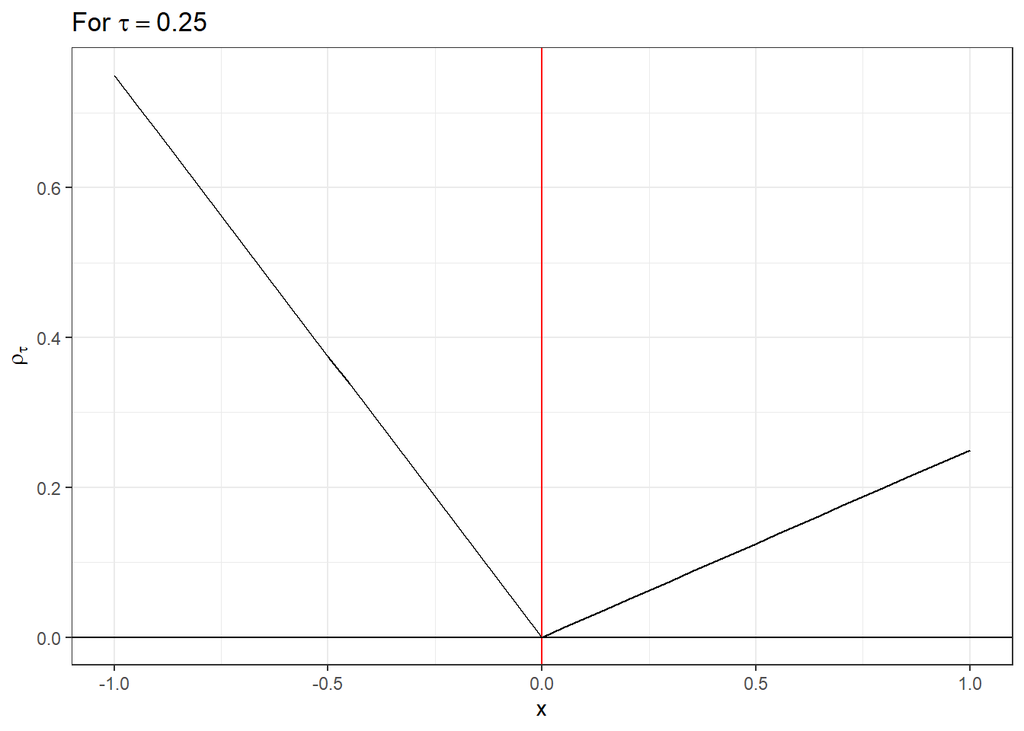

```r
# Define quantile loss function for later use.
loss_rho <- function(x, tau) x * (tau - (x < 0))

# Example for 25% quantile
x <- seq(-1, 1, by = 0.05)
y <- loss_rho(x, tau = 0.25)
data_loss <- cbind.data.frame(x, y)

data_loss %>%
  ggplot(mapping = aes(x, y)) +
  geom_line() +
  geom_vline(xintercept = 0, col = "red") +
  geom_hline(yintercept = 0) +
  theme_bw() +
  labs(x = "x", y = TeX("$\\rho_{\\tau}$"), title = TeX("For $\\tau = 0.25$"))
```